# Lab 7 Data Visualization using Matplotlib

- Overview of Matplotlib
- Basic Concept: Figure and Axes
- Visualizing Errors
- Multiple Subplots in a Figure

# Lab 7 Data Visualization using Matplotlib

- Overview of Matplotlib
- Basic Concept: Figure and Axes
- Visualizing Errors
- Multiple Subplots in a Figure

## What is **Matplotlib**?

### Matplotlib

- A popular plotting library in Python.
- Provides a set of drawing APIs through the pyplot module, and hides the complex structure composed of many drawing objects within this set of APIs.
- Different from other drawing software, we draw through programming!

### To install (https://matplotlib.org/users/installing.html):

- Use Anaconda’s GUI
- With Conda: conda install matplotlib
- With PyPl (Python Package Index): pip install -U matplotlib

### Reference:

- Examples: https://matplotlib.org/gallery/index.html
- User guide: https://matplotlib.org/tutorials/index.html

## Why Matplotlib?

- Good for data visualization
  - E.g., the "Charts" function in MS Excel
- Very powerful and flexible
  - Professional quality
  - Fully controlled by the programmer
- Platform independent
  - Windows, Linux, MacOS
  - Can export as many image types
- Many online free examples
  - https://matplotlib.org/gallery/index.html

```python
import matplotlib as mlt
import matplotlib.pyplot as plt
import numpy as np
```

### Examples

Creating 100 data points in `[0, 10]`. **Remark**: the NumPy function np.linspace(start, stop, num) returns a one-dimensional ndarray with num evenly spaced samples over the interval `[start, stop]`.

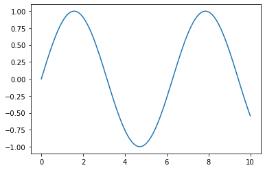

```python
x = np.linspace(0, 10, 100)
plt.plot(x, np.sin(x)) # draw a sin curve
```

```python
plt.plot(x, np.cos(x)) # draw a cos curve
```

### Example: Combine those curves in a figure

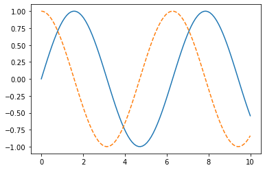

```python
x = np.linspace(0, 10, 100)
plt.plot(x, np.sin(x), '-')
plt.plot(x, np.cos(x), '--')
```

### Example: Save figure to a file

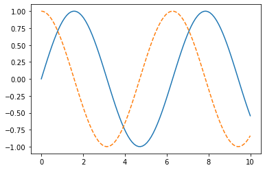

```python
x = np.linspace(0, 10, 100)
fig = plt.figure() # to create a new figure
plt.plot(x, np.sin(x), '-')
plt.plot(x, np.cos(x), '--')
fig.savefig('my_figure.png') # let's see the file in your disk
```

```python
fig.canvas.get_supported_filetypes() # try this to find out what image formats are supported
```

### Two Styles of using Matplotlib

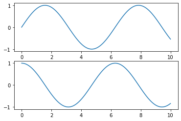

```python
plt.figure() # create a plot figure
plt.subplot(2, 1, 1) # (rows, column, panel number)
plt.plot(x, np.sin(x))
plt.subplot(2, 1, 2)
plt.plot(x, np.cos(x))
```

```python
# Object-oriented style
fig, ax = plt.subplots(2)
ax[0].plot(x, np.sin(x))
ax[1].plot(x, np.cos(x))
```

# Lab 7 Data Visualization using Matplotlib

- Overview of Matplotlib
- Basic Concept: Figure and Axes
- Visualizing Errors
- Multiple Subplots in a Figure

## Basic Concept: Figure and Axes

A **Figure** is the object that contains your figure. An **Axis** is an object of a bounding box with **x-axis** and **y-axis**. We can draw on an Axes.

[figure not shown]

### A figure with multi-axes

```python
fig = plt.figure() # create an empty Figure
ax1 = plt.axes() # create an Axes for the Figure
ax2 = fig.add_axes([0.5, 0.5, 0.2, 0.2]) # add another Axes
```

### Components of a Figure

[figure not shown]

### Line Plot (OO Style)

Now, let's try to draw a curve y = sin(x), where 0 <= x <= 10

Solution: Sample 1000 points in [0,10], calculate y = sin(x) for these 1000 points, and then join these (x,y) points by line segments. This is called **line plot**.

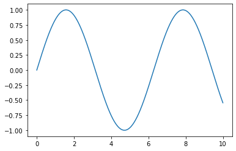

```python
fig, ax = plt.subplots()
x = np.linspace(0, 10, 1000) # 1000 points
ax.plot(x, np.sin(x))
```

### Line Plot (OO Style)

10 points

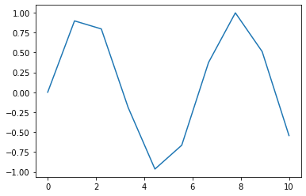

```python
fig, ax = plt.subplots()
x = np.linspace(0, 10, 10) # 10 points
ax.plot(x, np.sin(x))
```

### Styling Line Plot: Line Color

Changing line colors

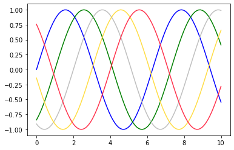

```python
# line colors
fig = plt.figure()
plt.plot(x, np.sin(x - 0), color='blue') # specify color by name
plt.plot(x, np.sin(x - 1), color='g') # short color code (rgbcmyk)
plt.plot(x, np.sin(x - 2), color='0.75') # Grayscale between 0 and 1
plt.plot(x, np.sin(x - 3), color='#FFDD44') # Hex code (RRGGBB from 00 to FF)
plt.plot(x, np.sin(x - 4), color=(1.0, 0.2, 0.3)) # RGB tuple, values 0 and 1
```

### Styling Line Plot: Line Style

changing line styles

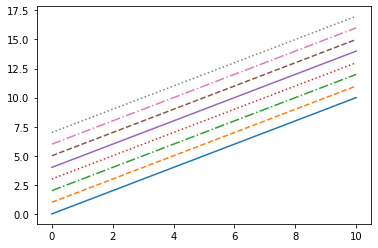

```python
fig = plt.figure()
plt.plot(x, x + 0, linestyle='solid')
plt.plot(x, x + 1, linestyle='dashed')
plt.plot(x, x + 2, linestyle='dashdot')
plt.plot(x, x + 3, linestyle='dotted')
# For short, you can use the following codes:
plt.plot(x, x + 4, linestyle='-') # solid
plt.plot(x, x + 5, linestyle='--') # dashed
plt.plot(x, x + 6, linestyle='-.') # dashdot
plt.plot(x, x + 7, linestyle=':'); # dotted
```

**Remark** If no color is specified, Matplotlib will automatically cycle through a set of default colors fro multiple lines.

### Styling Line Plot: Axes limits

Setting Axes limits

```python
fig = plt.figure()
x = np.linspace(0, 10, 1000)
plt.plot(x, np.sin(x))
```

```python
# try this
plt.xlim(-5, 15)
plt.ylim(-1.5, 1.5)
```

```python
# and we can also set the same Axes limits by
plt.axis([-5,15,-1.5,1.5])
```

### Styling Line Plot: Label

A figure can have many kinds of labels

- figure title: plt.title()
- axis labels: plt.xlabel(), plt.ylabel()
- legends: plt.legend()

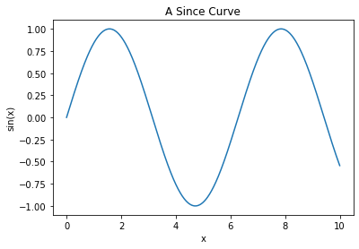

```python
# Labeling Plots
fig = plt.figure()
x = np.linspace(0, 10, 1000)
plt.plot(x, np.sin(x))
plt.title('A Since Curve')
plt.xlabel('x')
plt.ylabel('sin(x)')
```

### Styling Line Plot: Simple Legend

```python
fig = plt.figure()
x = np.linspace(0, 10, 1000)
```

To draw the legend, we can specify the label of each line using the label keyword of the plot() function. '-g' and ':b' are both handy combination of line style & color

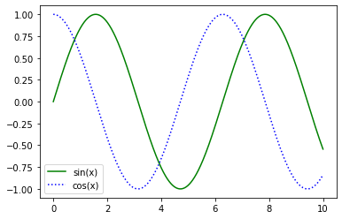

```python
plt.plot(x, np.sin(x), '-g', label='sin(x)')
plt.plot(x, np.cos(x), ':b', label='cos(x)')
plt.legend()
```

### MATLAB Style vs. Object-Oriented Style

Previously we are using MATLAB style. You can also try the object-oriented style, i.e., plot through Axes object.

- plt.plot() → ax.plot()
- plt.legend() → ax.legend()
- plt.xlabel() → ax.set_xlabel()
- plt.ylabel() → ax.set_ylabel()
- plt.xlim() → ax.set_xlim()
- plt.ylim() → ax.set_ylim()
- plt.title() → ax.set_title()

The Axes object has a powerful ax.set() function that can set everything: ax.set(xlim, ylim, xlable, ylabel, title)

- ax.set(xlim, ylim, xlable, ylabel, title)

```python
# Object-oriented Style
fig, ax = plt.subplots()
x = np.linspace(0, 10, 1000)
ax.plot(x, np.sin(x))
ax.set(xlim=(0, 10), ylim=(-2, 2), xlabel='x', ylabel='sin(x)', title='A Simple Plot')
```

### Annotating a Plot

Ref: https://matplotlib.org/api/_as_gen/matplotlib.axes.Axes.annotate.html

```python
fig, ax = plt.subplots()
t = np.arange(0.0, 5.0, 0.01)
s = np.cos(2*np.pi*t)
ax.plot(t, s, lw=2)
ax.annotate('local max', xy=(2, 1), xytext=(3, 1.5), arrowprops=dict(facecolor='black', shrink=0.05))
ax.set_ylim(-2, 2)
```

- `xy` specifies the location of the annotation;
- `xytext` specifies the location of the text;
- `arrowprops` specifies the arrow between xytext and xy.

### Scatter plots

In a scatter plot, the data points are represented individually with a dot or circle or other shape. In Matplotlib, we can draw scatter plots using either **plt.plot()** or **plt.scatter()**.

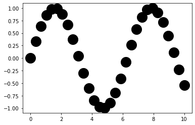

```python
x = np.linspace(0, 10, 30)
y = np.sin(x)
plt.plot(x, y, 'o', color='black', markersize=20)
```

The parameter 'o' tells plot() to draw a scatter instead of line. It represents the type of symbol used for the data point. Another optional parameter markersize controls the size of the marker.

### More Symbols for Scatter Plots

```
(0, 1.8)
```

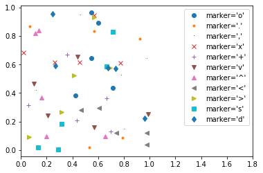

```python
rng = np.random.RandomState(0)
for marker in ['o', '.', ',', 'x', '+', 'v', '^', '<', '>', 's', 'd']:
    plt.plot(rng.rand(5), rng.rand(5), marker, label="marker='{0}'".format(marker))
plt.legend(numpoints=1)
plt.xlim(0, 1.8)
```

- rng.rand(5) returns a list of 5 random numbers.
- the numpoints=1 in legend() means that only 1 symbol is shown in each legend

### Scatter plots with plt.scatter()

On the one hand, plt.scatter() can be used in a similar way to plt.plot(). On the other hand, plt.scatter() allows to control each individual point (size, color, etc.). It is more powerful, but could be slower if you have huge amount of points to plot.

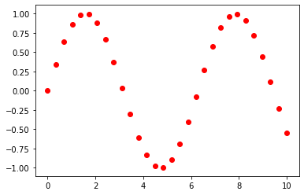

```python
x = np.linspace(0, 10, 30)
y = np.sin(x)
plt.scatter(x, y, marker='o', color='red')
```

### Scatter Plots: Plot 100 random points with random sizes and colors

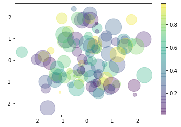

```python
rng = np.random.RandomState(0)
x, y, colors, sizes = rng.randn(100), rng.randn(100), rng.rand(100), 1000 * rng.rand(100)
plt.scatter(x, y, c=colors, s=sizes, alpha=0.3,cmap='viridis')
plt.colorbar() # show color scale
```

1. rng.randn(100) returns a list of 100 random numbers with standard normal distribution; while `rng.rand(100)` returns a list of 100 random numbers in `[0, 1]`.
2. In `plt.scatter()`, parameters c and s can set the color and size of each individual point.
3. cmap: colormap, defines how to map a value to a color.
4. `alpha=0.3` makes the circles transparent.

More about colormap in Matplotlib: https://matplotlib.org/3.2.0/tutorials/colors/colormaps.html

### Object-Oriented Style: axes.scatter()

Ref: https://matplotlib.org/3.1.1/api/_as_gen/matplotlib.axes.Axes.scatter.html

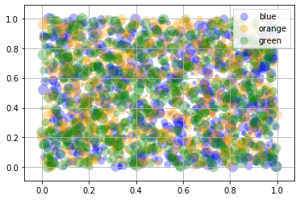

```python
np.random.seed(19680801)
fig, ax = plt.subplots()
for color in ['blue', 'orange', 'green']:
    n = 750
    x, y = np.random.rand(2, n)
    scale = 200.0 * np.random.rand(n)
    ax.scatter(x, y, s=scale, c=color, label=color, alpha=0.3, edgecolors='none')
ax.legend()
ax.grid(True)
```

1. x, y = np.random.rand(2, n) returns two sequences to x and y, each with n random numbers.
2. ax.grid(True) show the grid lines.

### Plot Bar Chart with plt.bar()

Ref: https://matplotlib.org/3.1.1/api/_as_gen/matplotlib.pyplot.bar.html

```
 <a list of 4 Text xticklabel objects>)
```

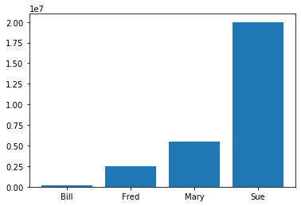

```python
x, money = np.arange(4), [1.5e5, 2.5e6, 5.5e6, 2.0e7]
plt.bar(x, money)
plt.xticks(x, ('Bill', 'Fred', 'Mary', 'Sue'))
```

1. In plt.bar(), the first parameter x specifies the x-coordinates of the bars; and the 2nd parameter money specifies the heights of the bars.
2. plt.xticks() can set the current tick locations and labels of the x-axis.

### Horizontal bar chart with plt.barh()

Ref: https://matplotlib.org/3.1.1/api/_as_gen/matplotlib.pyplot.barh.html

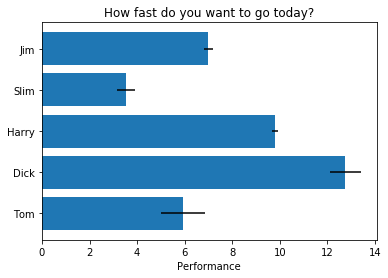

```python
people = ('Tom', 'Dick', 'Harry', 'Slim', 'Jim')
y_pos, performance, error = np.arange(len(people)), 3 + 10 * np.random.rand(len(people)), np.random.rand(len(people))
plt.barh(y_pos, performance, xerr=error, align='center')
plt.yticks(y_pos, people)
plt.xlabel('Performance')
plt.title('How fast do you want to go today?')
```

### Grouped Bar Chart with Axes.bar()

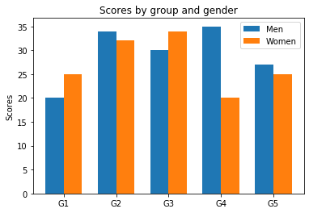

```python
labels, men_means, women_means = ['G1', 'G2', 'G3', 'G4', 'G5'], [20, 34, 30, 35, 27], [25, 32, 34, 20, 25]
x = np.arange(len(labels))  # the label locations
width = 0.35  # the width of the bars
fig, ax = plt.subplots()
rects1 = ax.bar(x - width/2, men_means, width, label='Men')
rects2 = ax.bar(x + width/2, women_means, width, label='Women')
# Add some text for labels, title and custom x-axis tick labels, etc.
ax.set_ylabel('Scores')
ax.set_title('Scores by group and gender')
ax.set_xticks(x)
ax.set_xticklabels(labels)
ax.legend()
```

# Lab 7 Data Visualization using Matplotlib

- Overview of Matplotlib
- Basic Concept: Figure and Axes
- Visualizing Errors
- Multiple Subplots in a Figure

## Visualizing Errors

In many applications, we need to report a measurement with augmented uncertainties. E.g., 80±2 (km/s), 65±1 kg, etc. When visualizing the results, showing the errors can convey more complete information. Next, we show an example of plotting a scatter figure with error bars.

### Plot Error Bars by plt.errorbar()

```
<ErrorbarContainer object of 3 artists>
```

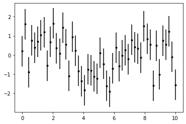

```python
x, dy = np.linspace(0, 10, 50), 0.8
y = np.sin(x) + dy * np.random.randn(50) # introduce random errors to y = np.sin(x)
plt.errorbar(x, y, yerr=dy, fmt='.k')
```

1. In plt.errorbar(), parameters yerr sets the errorbar size (which can be a scalar or an array); fmt sets the format of the data points in a similar way to plt.plot(). 'k'  'black'.
2. For more details, check the reference at https://matplotlib.org/api/_as_gen/matplotlib.pyplot.errorbar.html

### Plot Pie Chart with plot.pie()

Ref: https://matplotlib.org/3.2.0/api/_as_gen/matplotlib.pyplot.pie.html

```
 [Text(-0.4993895680663527, 0.9801071672559598, 'Frogs'),
 [Text(-0.2723943098543742, 0.5346039094123416, '15.0%'),
```

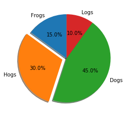

```python
labels, sizes = ['Frogs', 'Hogs', 'Dogs', 'Logs'], [15, 30, 45, 10]
explode = (0, 0.1, 0, 0)  # only "explode" the 2nd slice (i.e. 'Hogs')
plt.pie(sizes, explode=explode, labels=labels, autopct='%1.1f%%', shadow=True, startangle=90)
```

1. The 1st parameter sizes specifies the size of each wedge. The fractional area of each wedge is given by x/sum(x).
2. autopct (if specified) specifies the format of the numerical value shown inside the wedges.

### Plot Histograms by plt.hist()

Histogram can be a great first step in understanding a dataset. Ref: https://matplotlib.org/3.2.0/api/_as_gen/matplotlib.pyplot.hist.html

a simple histogram

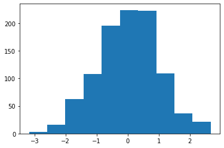

```python
data = np.random.randn(1000)
plt.hist(data)
```

### Plot Histograms by plt.hist()

customized histogram

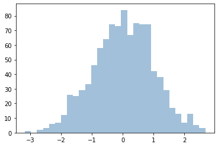

```python
plt.hist(data, bins=30, alpha=0.5, histtype='stepfilled', color='steelblue', edgecolor='none')
```

### Plot Histograms by plt.hist()

Plot Multiple Histograms, **np.random.normal(A, B, N)** generates N random numbers from a normal distribution with mean of A and standard deviation of B.

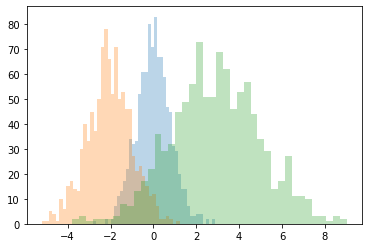

```python
x1, x2, x3 = np.random.normal(0, 0.8, 1000), np.random.normal(-2, 1, 1000), np.random.normal(3, 2, 1000)
kwargs = dict(histtype='stepfilled', alpha=0.3, bins=40)
plt.hist(x1, **kwargs)
plt.hist(x2, **kwargs)
plt.hist(x3, **kwargs)
```

# Lab 7 Data Visualization using Matplotlib

- Overview of Matplotlib
- Basic Concept: Figure and Axes
- Visualizing Errors
- Multiple Subplots in a Figure

## Multiple Subplots in a Figure

Sometimes we need to include multiple Axes (or called subplots) in a single Figure. There are several ways to do that.

- plt.axes()
- Figure.add_axes()
- plt.subplot()
- plt.subplots()
- plt.GridSpec()

[figure not shown]

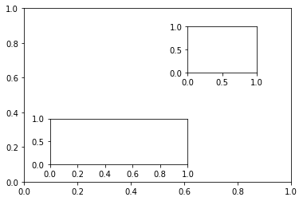

```python
# Subplots by Hand: plt.axes()

# plt.axes() takes an optional argument that is a list of four numbers
#   [bottom, left, width, height] in the figure coordinate system,
#   which range from 0 at the bottom left of the figure
#                 to 1 at the top right of the figure

ax1 = plt.axes() # standard axes
ax2 = plt.axes([0.6, 0.6, 0.2, 0.2])
ax3 = plt.axes([0.2, 0.2, 0.4, 0.2])

# plt.axes() is equivalent to the object-oriented style figure.add_axes().
```

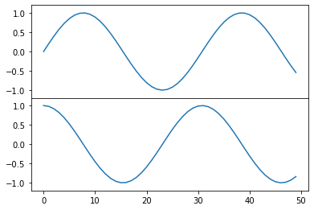

```python
# Subplots by Hand: Figure.add_axes()

fig = plt.figure()
ax1 = fig.add_axes([0.1, 0.5, 0.8, 0.4], xticklabels=[], ylim=(-1.2, 1.2))
ax2 = fig.add_axes([0.1, 0.1, 0.8, 0.4], ylim=(-1.2, 1.2))
x = np.linspace(0, 10)
ax1.plot(np.sin(x))
ax2.plot(np.cos(x))

# Remark:
# We need to set the size and location carefully to make the two subplots well aligned
# E.g., the y-coordinate of ax1 (i.e., 0.5) is equal to the y-coordinate of
# ax2 (i.e., 0.1) + the height of ax2 (i.e., 0.4).
```

### Plot a Grid of Subplots with plt.subplot()

It's a common pattern to organize the subplots as a grid. **plt.subplot()** takes three arguments: # of rows, # of columns, and the index of the plot to be created The index begins with 1 and runs from the upper left to the bottom right

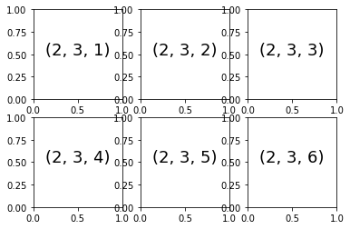

```python
# Plot a Grid of Subplots with plt.subplot()

fig = plt.figure()
for i in range(1, 7):
    plt.subplot(2, 3, i)
    plt.text(0.5, 0.5, str((2, 3, i)), fontsize=18, ha='center')

# Remark:
# plt.text() can show a text in the current Axes. The argument ha refers to
#   horizontalalignment.

# BUT problem is:
#    the subplots are too crowded!
```

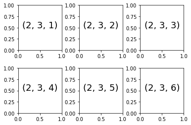

```python
# plt.subplots_adjust() can be used to adjust the spacing between these plots.
# The hspace and wspace arguments specify the spacing along the height and
#    width of the figure, in units of the subplot size.

fig = plt.figure()
fig.subplots_adjust(hspace=0.4, wspace=0.4)
for i in range(1, 7):
    ax = fig.add_subplot(2, 3, i)
    ax.text(0.5, 0.5, str((2, 3, i)), fontsize=18, ha='center')

# BUT problem is:
#    plotting the subplots one by one is two tedious!
```

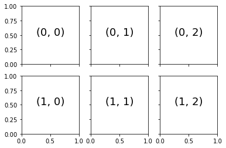

```python
# Plot a Grid of Subplots with plt.subplots()
# Ref: https://matplotlib.org/3.2.0/api/_as_gen/matplotlib.pyplot.subplots.html
# plt.subplots() creates a full grid of subplots in a single line, returning
#    a Figure object and an array of Axes objects

fig, ax = plt.subplots(2, 3, sharex='col', sharey='row')
for i in range(2):
    for j in range(3):
        ax[i, j].text(0.5, 0.5, str((i, j)), fontsize=18, ha='center')

# Remark:
# The first two arguments specify the number of rows and the number of
#    columns of the grid, respectively.
# sharex = 'col' means sharing the x tick labels for each column.
# sharey = 'row' means sharing the y tick labels for each row.
```

### Plot Multiple Subplots with plt.GridSpec() and plt.subplot()

Problem: When we use plt.subplots(), all plots have the same size. But sometimes we want to be more flexible.

**plt.GridSpec()** will "cut" a Figure into a grid of blocks, and then allow **plt.subplot()** to generate an Axes on top of multiple blocks.

[figure not shown]

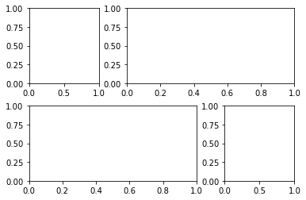

```python
# Plot Multiple Subplots with plt.GridSpec() and plt.subplot()
# Ref: https://matplotlib.org/3.1.1/api/_as_gen/matplotlib.gridspec.GridSpec.html

grid = plt.GridSpec(2, 3, wspace=0.4, hspace=0.3)
plt.subplot(grid[0, 0])
plt.subplot(grid[0, 1:])
plt.subplot(grid[1, :2])
plt.subplot(grid[1, 2])
```

[figure not shown]

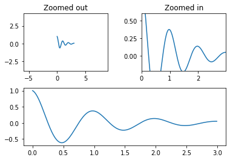

```python
# Plot Multiple Subplots with plt.GridSpec() and Axes.add_subplot()

def f(t):
    return np.exp(-t) * np.cos(2*np.pi*t)

t1 = np.arange(0.0, 3.0, 0.01)

fig = plt.figure()
grid = plt.GridSpec(2, 2, wspace=0.4, hspace=0.3)
ax1 = fig.add_subplot(grid[1, :])
ax1.margins(0.05)           # Default margin is 0.05, value 0 means fit
ax1.plot(t1, f(t1))

ax2 = fig.add_subplot(grid[0, 0])
ax2.margins(2, 2)           # Values >0.0 zoom out
ax2.plot(t1, f(t1))
ax2.set_title('Zoomed out')

ax3 = fig.add_subplot(grid[0, 1])
ax3.margins(x=0, y=-0.25)   # Values in (-0.5, 0.0) zooms in to center
ax3.plot(t1, f(t1))
ax3.set_title('Zoomed in')
```